# Steam 新游市场与玩家评论统计分析

Steam Game Market & Player Review Analytics — Full Statistical Analysis Report

# 1 封面与执行摘要

> **项目定位**：这是一个从 Steam 数据采集、关系型数据库、SQL 探索到 R 统计建模的完整分析项目。报告中的结果都是当前 3,000 款游戏快照上的条件关联，不代表销售、收益或因果效果。

## 1.1 执行摘要

本项目分析了 2025 年下半年（2025-07-01 至 2025-12-31）Steam 新发行游戏的市场结构、玩家评论关注度（attention）和玩家口碑（reception）。从 10,115 个候选游戏中按发布月份进行比例分层抽样，得到 3,000 款游戏；其中 402 款免费、2,598 款付费，759 款（25.30%）没有任何评论。评论量不是销量或拥有量，而是购买者评论关注度的代理指标。

市场最显著的结构是极端长尾：有评论游戏的评论量中位数为 10，均值为 481.69，最大值为 136,842，Gini 系数为 0.953；前 1% 游戏吸收约 65.44% 的评论量。这个结构使得直接对 raw count 拟合普通 Poisson、Negative Binomial 或 zero-truncated NB2 都需要非常谨慎。Step 6B 原始 count 模型保留为诊断案例，但没有冻结。

Reception 部分使用携带正面/负面评论分母的 Beta-binomial regression 作为主要推断模型。标准 Binomial 的 Pearson dispersion 约为 73.52，说明游戏之间存在严重额外异质性。Beta-binomial 在 836 款 paid、至少 20 条评论的游戏上收敛良好，估计的 `phi≈8.747`、`rho≈0.103`。在该模型中，价格与正面评价倾向呈弱负关联；Simulation 是稳定的负向 reception 关联，而 Strategy 也总体负向但敏感性略高。

Rating reliability 部分显示，raw positive rate 不能脱离 denominator 解读：`1/1=100%` 的 Wilson lower 只有约 20.65%，而 `1000/1000=100%` 的 Wilson lower 约为 99.62%。Empirical Bayes 以 Beta(5.022, 1.045) 为总体先验，低评论量游戏收缩更强；评论量与绝对收缩的 Spearman 相关约为 -0.912。

Attention 采用两阶段 hurdle 思路。Stage 1 的 review-entry 模型保留非线性 paid-price spline；线性价格模型 AIC 为 2387.87，df=3 spline 为 2373.03，中央支持区的拟合峰值约为 $14.92，但这是宽平台上的描述性最大值，不是“最佳定价”。Stage 2 将正评论游戏按 1–9、10–99、100–999、1000+ 分成四个有序 attention tiers，用 cumulative ordinal logistic 描述进入更高关注等级的关联，并用 High-100 logistic（至少 100 条评论）做稳健性检查。Proportional-odds 假设为 APPROXIMATE，但没有 major direction reversal，High-100 方向广泛一致，因此该 tier model 已冻结。

最终结论不是“某个价格导致成功”或“某类游戏天然更差”，而是：市场关注度与玩家口碑是两个不同维度；可靠的分析需要保留 denominator、承认 overdispersion、检查 functional form，并在诊断不通过时改变 estimand，而不是强行冻结一个漂亮但不可信的模型。

# 2 研究问题与分析路线

## 2.1 四个研究问题

### 2.1.1 RQ1 — Market Structure

2025 年下半年 Steam 新发行游戏的价格、平台、类型、评论覆盖率和评论量分布具有什么市场结构？

### 2.1.2 RQ2 — Attention

哪些游戏更可能获得至少一条玩家评论，并在获得评论后进入更高的评论关注等级？

### 2.1.3 RQ3 — Reception

在有足够评论后，价格、平台和游戏类型与玩家正面评价倾向之间存在怎样的条件关联？

### 2.1.4 RQ4 — Rating Reliability

当评论样本较少时，如何避免直接使用 raw positive rate 造成过度乐观或错误排序？

## 2.2 端到端数据管线

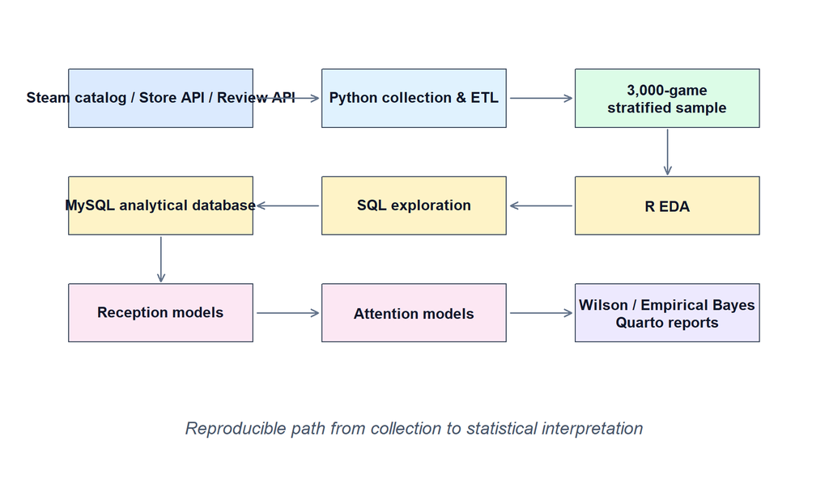

图 1: 从 Steam 数据采集到统计解释的可复现路径。应该看什么：每个后续模型都建立在明确的样本和数据库层之上。

项目使用 Python 完成采集和 ETL，MySQL 保存分析型关系数据，SQL 负责只读探索，R 负责 EDA、模型和诊断，Quarto 负责可复现报告，Git 负责版本控制。报告不展示连接密码、用户名或 console 日志。

# 3 数据来源、抽样与语义

## 3.1 抽样设计

候选池包含 10,115 个在研究窗口内发布的游戏。最终样本为 3,000 款，按发布月份进行比例分层抽样，随机种子为 `20250911`。按月份分层的目的，是避免某一个月份因发行量或暴露时间不同而过度代表整体。

样本构造与分析层级

| 指标 | 数量 | 说明 |
| --- | --- | --- |
| 候选游戏 | 10115 | 2025-07-01 至 2025-12-31 候选池 |
| 最终样本 | 3000 | 按发布月份比例分层抽样 |
| 免费游戏 | 402 | 完整市场构成 |
| 付费游戏 | 2598 | 完整市场构成 |
| 零评论 | 759 | 市场层 outcome |
| 至少一条评论 | 2241 | 市场层 attention |
| 评论量模型 20+ | 844 | Reception 预设候选样本 |

月度样本数为：2025-07 `497`、2025-08 `470`、2025-09 `427`、2025-10 `544`、2025-11 `580`、2025-12 `482`。

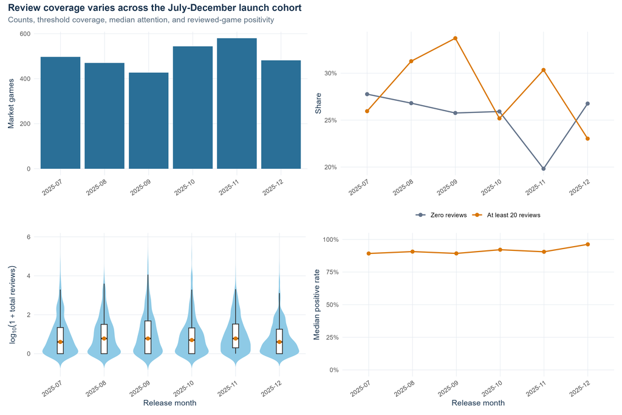

图 2: 按发布月份的样本覆盖。应该看什么：月份样本量不同，因此月度差异需要结合暴露时间和构成解释。

## 3.2 数据语义与解释边界

- **Price** 是采集时点的 US storefront current price，不是首发价、历史价格或 reviewer-paid price。
- **total_reviews** 是 Steam 购买者评论关注度/互动代理，不是销量、owners、收入或商业成功。
- **Early Access** 是 Steam taxonomy label，不是已经验证的 historical Early Access 状态。
- 游戏类型是 **multi-label**，类型计数不能当作互斥类别相加。
- 这是 single-snapshot observational design；所有 predictor 结果都称为 association 或 conditional association，不称为 impact、effect 或 cause。

# 4 市场结构与评论长尾

## 4.1 市场概览

完整市场包含 `N=3,000` 款游戏：免费 402（13.40%），付费 2,598（86.60%）；759 款没有评论，2,241 款至少有一条评论。

3,000 款游戏的市场层概览

| 指标 | 数值 |
| --- | --- |
| 总游戏 | 3000 |
| 免费 | 402 |
| 付费 | 2598 |
| 至少一条评论 | 2241 |
| 零评论 | 759 |
| 零评论比例 | 25.3% |

付费游戏当前价格中位数为 `$4.99`，均值为 `$8.52`；价格分布右偏且在低价带高度集中。

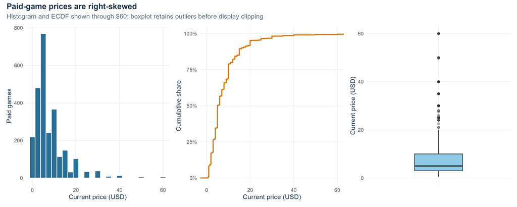

图 3: 完整样本中的价格分布。应该看什么：价格右偏且是 collection-time snapshot，不能直接解释为最优价格。

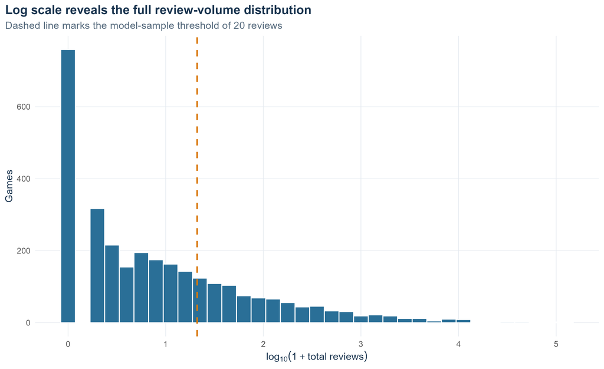

图 4: 评论量的 log-scale 分布。应该看什么：大量游戏集中在低评论量区间，少数头部游戏形成极长右尾。

## 4.2 评论量的 winner-takes-most 结构

完整市场评论量中位数为 4；在 positive-count population 中，中位数为 10，均值为 481.69，最大值为 136,842。Top 1 游戏占 12.68%，Top 1% 游戏占 65.44%，Top 5% 占 89.01%，Top 10% 占 94.52%，Gini 为 0.953。

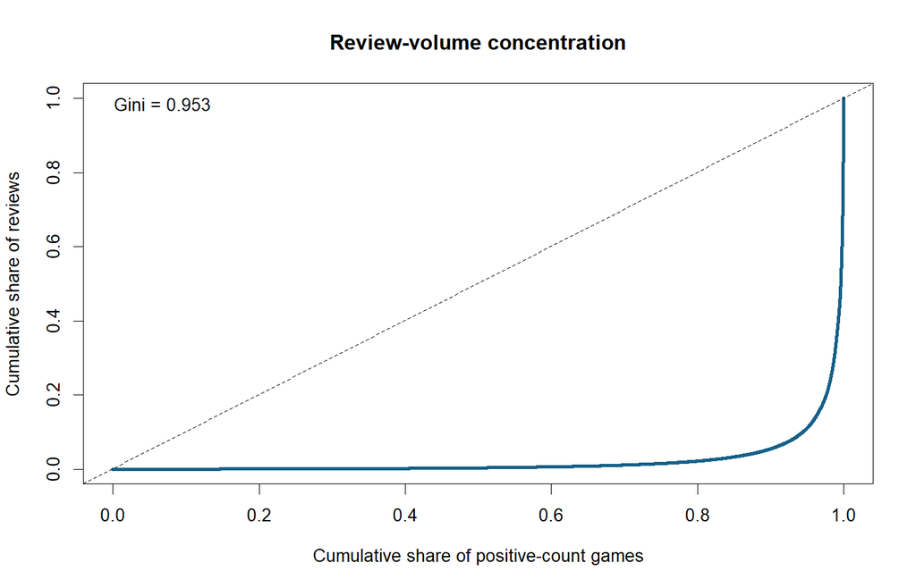

图 5: 评论关注度的集中度。应该看什么：少数头部游戏吸收了绝大部分评论量，因此 raw count 的单一回归系数很容易被头部支配。

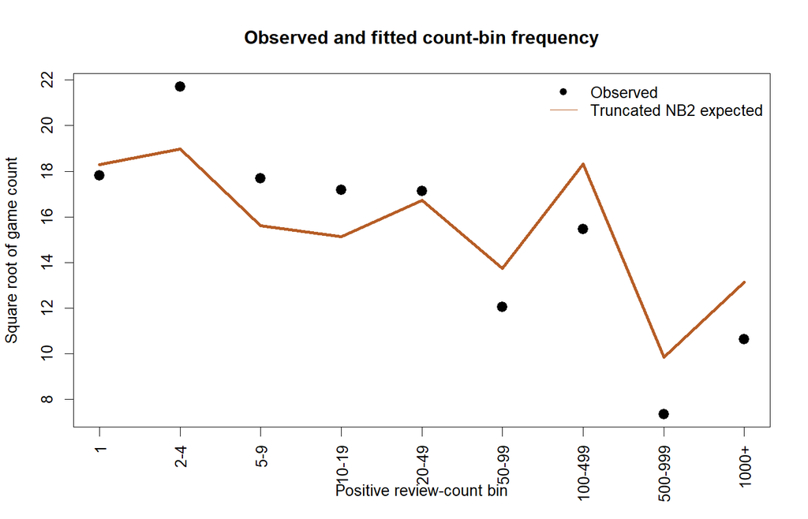

图 6: 计数模型的 observed-versus-fitted 诊断。应该看什么：即使 truncated NB2 AIC 较低，分布拟合和尾部行为仍不足以自动冻结。

# 5 Reception：从 Binomial 到 Beta-binomial

## 5.1 为什么 raw positive rate 不够

正面率的基本形式为

$$p_i = \frac{y_i}{n_i}.$$

但相同的 `p=1` 并不代表相同的统计证据。评论分母同时决定比例精度，因此后续 reception 模型使用 grouped response `(positive_reviews, negative_reviews)`，而不是把每个 raw rate 当成同等精度的连续观测。

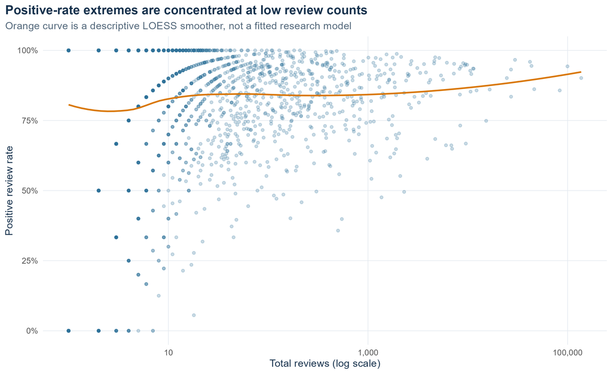

图 7: 正面率与评论量的关系。应该看什么：低分母游戏更容易出现 0% 或 100% 极值，不能与大分母游戏等量齐观。

## 5.2 Reception modeling journey

### 5.2.1 Binomial benchmark

冻结的标准 Binomial 作为 benchmark，但 Pearson dispersion 约为 `73.52`，deviance/df 约为 `61.82`。这意味着标准误和区间会系统性过于乐观。

### 5.2.2 Quasibinomial

Quasibinomial 将标准误放大约 `sqrt(phi)=8.57` 倍，point estimates 与 Binomial 基本相同。它能修正 variance scale，却不能完整刻画 latent heterogeneity，也不能解决不同 denominator 带来的贡献差异。

### 5.2.3 Beta-binomial primary model

Beta-binomial 在 `N=836` 个 paid games（每款至少 20 条评论）上作为最终 reception primary inferential model。模型收敛，`phi≈8.747`，派生的 within-game ICC `rho≈0.103`。表中的区间优先使用 profile-likelihood interval。

Beta-binomial reception 的代表性 OR 与 profile 95% CI

|  | Predictor | OR | CI low | CI high |
| --- | --- | --- | --- | --- |
| 2 | z_log1p_price | 0.930 | 0.873 | 0.990 |
| 3 | z_days_since_release | 0.983 | 0.925 | 1.044 |
| 4 | platform_segmentWindows + macOS | 1.443 | 1.172 | 1.795 |
| 5 | platform_segmentWindows + Linux | 1.632 | 1.196 | 2.298 |
| 6 | platform_segmentWindows + macOS + Linux | 1.519 | 1.225 | 1.909 |
| 12 | genre_simulation | 0.786 | 0.692 | 0.894 |
| 13 | genre_strategy | 0.826 | 0.714 | 0.957 |
| 10 | genre_indie | 1.145 | 0.998 | 1.310 |
| 11 | genre_rpg | 0.917 | 0.801 | 1.051 |

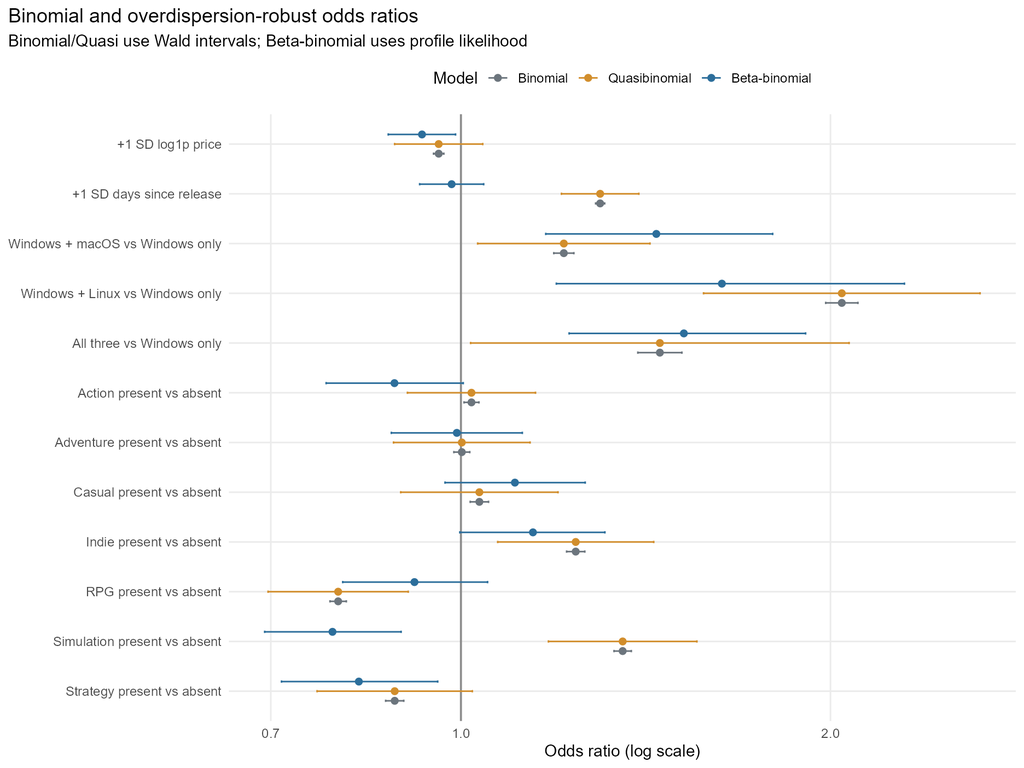

图 8: Overdispersion-robust reception odds ratios。应该看什么：价格弱负向、Simulation 稳定负向；不要把 OR 解释成因果效应。

## 5.3 Reception findings 与敏感性

- **Price**：在 Beta-binomial 中为弱但稳定的负向关联，OR 约 `0.930 [0.873, 0.990]`（每一标准差 log-price）。
- **Simulation**：Beta-binomial OR `0.786 [0.692, 0.894]`，而 misspecified Binomial OR 约 `1.354`，发生方向反转。这是“模型假设会改变实质结论”的典型案例。
- **Strategy**：总体负向，Beta-binomial OR 约 `0.826 [0.714, 0.957]`，但相对敏感性略高。
- **Platform**：多平台组合呈正向，但 magnitude 对模型规格敏感，可能反映未观测的开发资源、团队成熟度或发行策略。
- **Indie / RPG**：区间跨 1 或证据较弱，不作强结论。

Step 5D 比较了 `>0`、`>=10`、`>=20`、`>=50` 评论阈值，以及 raw price、release month、genre expansion 和 head-game sensitivity。核心方向整体保留，但不同阈值改变 estimand，因此不能用跨样本 AIC 选择“最佳阈值”。

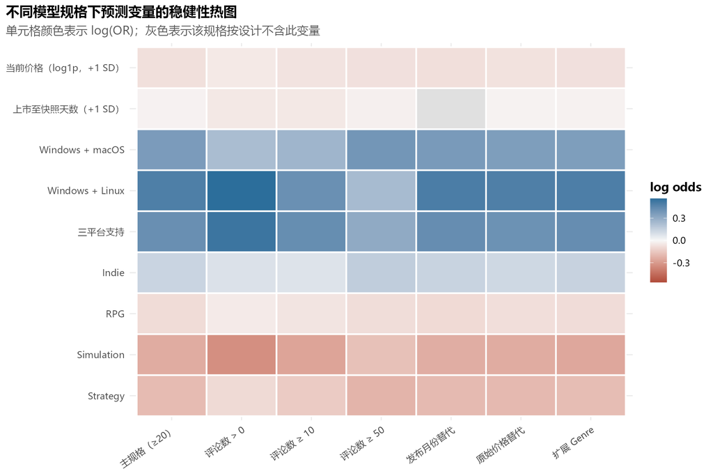

图 9: 预设 sensitivity 的方向与区间汇总。应该看什么：价格和 Simulation 的主要方向跨规格较稳定，Strategy 和部分平台项更敏感。

## 5.4 High-rating secondary model

Step 5E 将 `positive_rate >= 85%` 定义为 secondary business-readable outcome，并检查 80%/90% 阈值敏感性。HIGH85 样本为 471/836，样本内 AUC 约 `0.661`。该模型用于易读的二元补充描述，不替代 Beta-binomial；阈值之间不能用 AIC/BIC 选择“最佳阈值”。

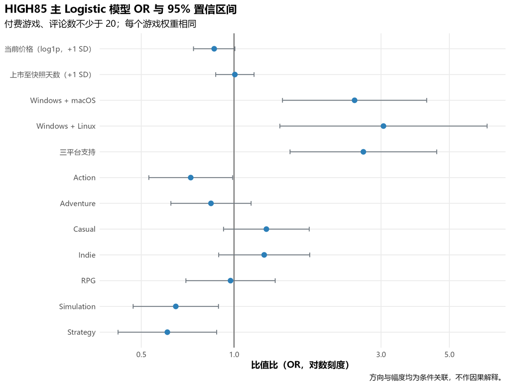

图 10: High-rating secondary logistic model。应该看什么：这是便于解释的补充模型，不是 reception primary inferential model。

# 6 Rating reliability：Wilson 与 Empirical Bayes

## 6.1 Wilson interval

Wilson score interval 只改变不确定性表达，不改变 raw point estimate。两个极端例子是：

- `1/1=100%`，Wilson lower 约 `20.65%`；
- `1000/1000=100%`，Wilson lower 约 `99.62%`。

因此，相同的 raw 100% rating 在不同 denominator 下代表完全不同的证据强度。

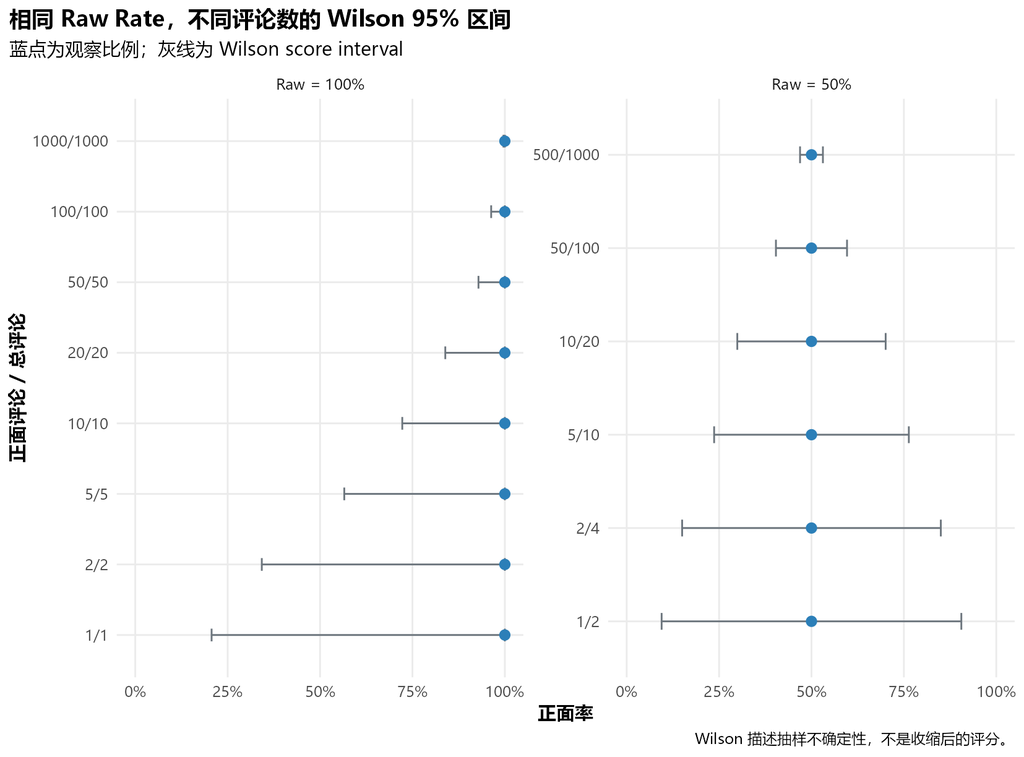

图 11: Wilson denominator geometry。应该看什么：分母从 1 增至 1,000 时，100% raw rate 的下界迅速收紧。

## 6.2 Empirical Bayes rating adjustment

Empirical Bayes 使用全体 `n>0` 游戏估计 Beta prior：`Beta(5.022, 1.045)`，prior mean 约 `82.78%`，ESS 约 `6.07`。后验均值为

$$E[p_i\mid y_i,n_i] = \frac{y_i+\alpha}{n_i+\alpha+\beta}.$$

低评论量游戏受到更强 shrinkage，高评论量游戏几乎不变。评论量与绝对收缩的 Spearman 相关为 `-0.912`；1,000+ reviews 游戏的 median absolute shrinkage 约 `0.017` 个百分点。

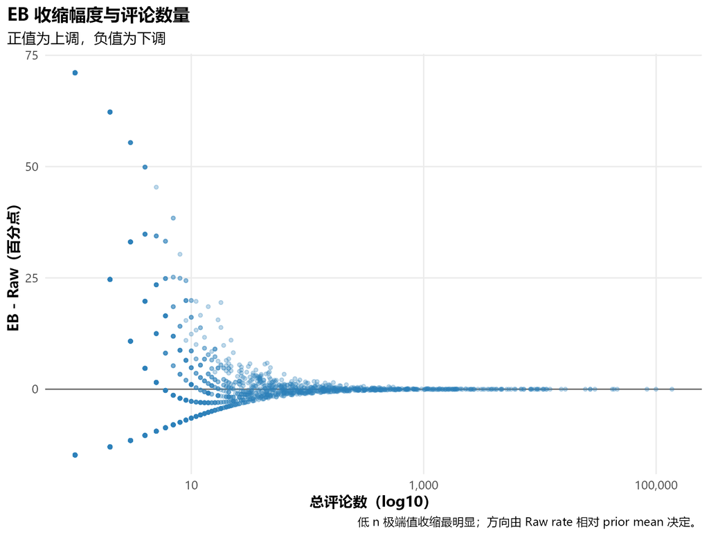

图 12: Empirical Bayes shrinkage 与评论量。应该看什么：低分母评分被拉回总体先验，高分母评分基本保持不变。

## 6.3 Raw ranking 与 reliability-aware ranking

Raw vs Wilson、Raw vs EB、Wilson vs EB 的 Spearman 相关分别约为 `0.2395`、`0.7761`、`0.6725`。Raw ranking 很大程度受低 denominator 的 100% ties 影响；832 款游戏的 raw rate 为 100%，其中 762 款虽然 raw rate 至少 95%，但 Wilson lower 低于 80%。

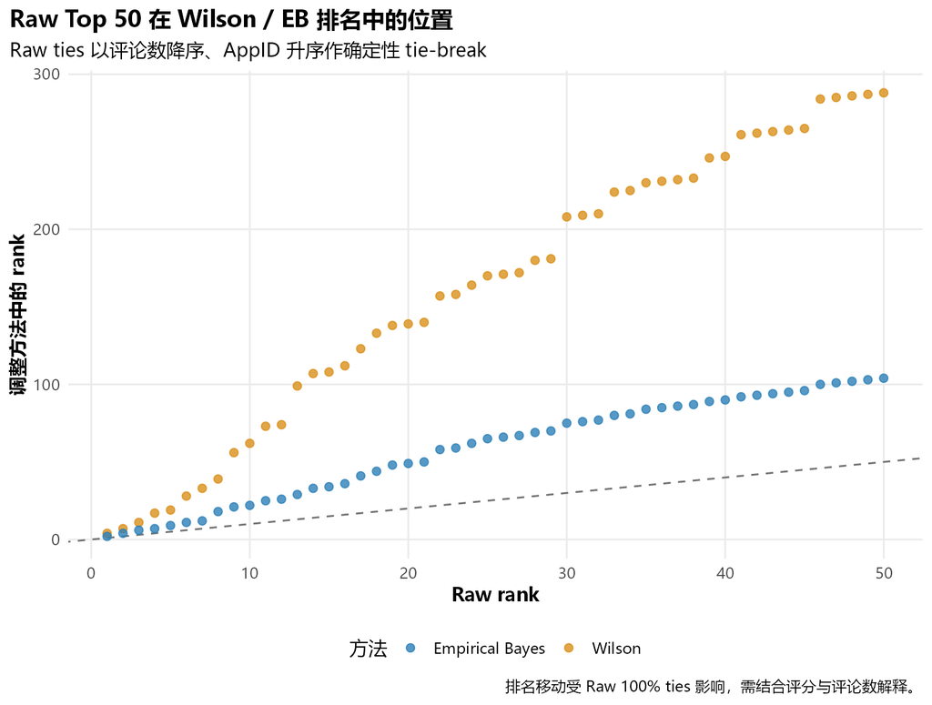

图 13: Raw、Wilson 与 EB ranking 的比较。应该看什么：可靠性调整会明显改变低分母游戏的排序，但不是把 EB 分数称为真实质量。

# 7 Attention：从 review entry 到 intensity

## 7.1 Hurdle structure

Attention 被拆成两个 estimand：

1. **Stage 1**：`P(Y>0)`，游戏能否获得至少一条评论；
2. **Stage 2**：在 `Y>0` 条件下，进入更高 attention intensity 的关联。

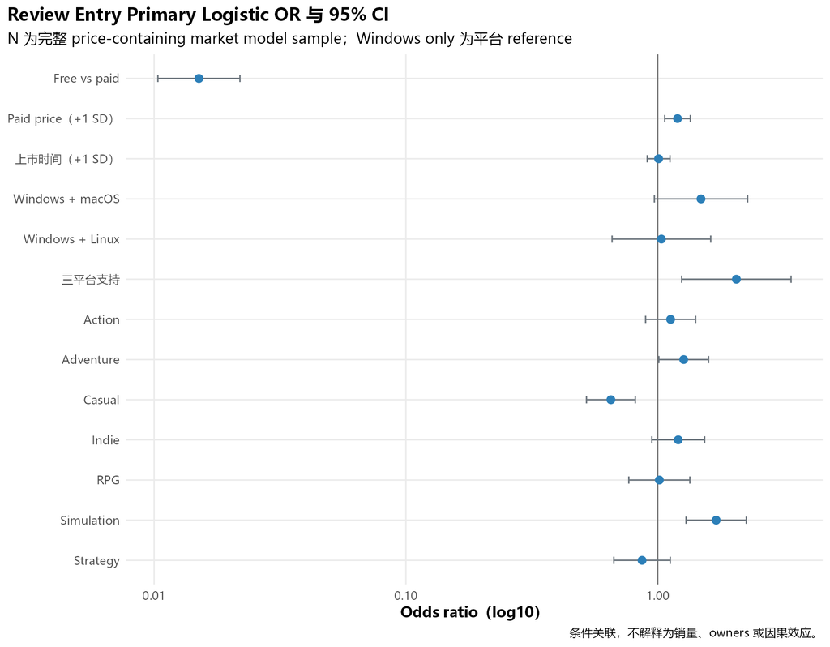

图 14: Review-entry logistic 的主要关联。应该看什么：free 与 paid 的构成差异很大，不能把 free OR 解释成 pricing 的因果效应。

Stage 1 中，free has-review rate 为 `8.46%`，paid 为 `84.95%`。这说明 free/paid 构成差异巨大；它可能同时反映受众、发行策略、可发现性、质量和开发成熟度等因素。

## 7.2 Nonlinear price specification for entry

Step 6A.1 保留 logistic framework，仅把 paid-price linear term 换为 centered Natural Spline（df=3）。Linear AIC 为 `2387.87`，spline AIC 为 `2373.03`，`Delta AIC≈-14.84`。拟合曲线在约 `$14.92` 达到 pointwise maximum，但 `$11.07–$20.30` 是宽 plateau，不能称为“最佳定价”。

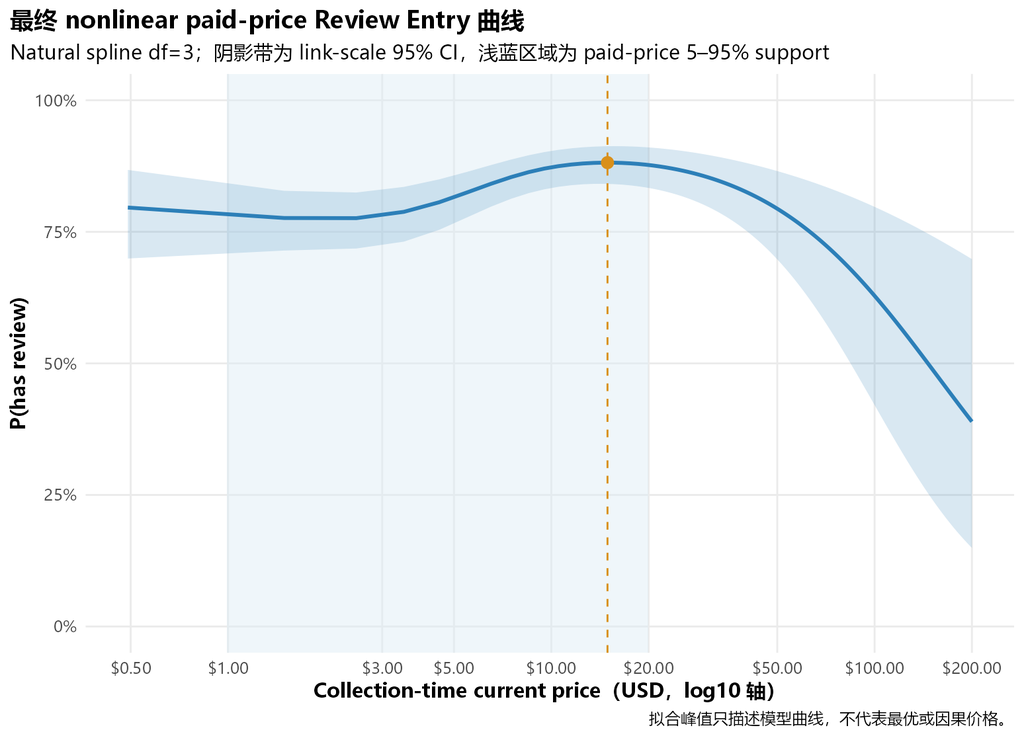

图 15: Paid-price 的非线性 review-entry 曲线。应该看什么：中央支持区呈宽平台，高价尾部稀疏，不应将峰值解释成最优价格。

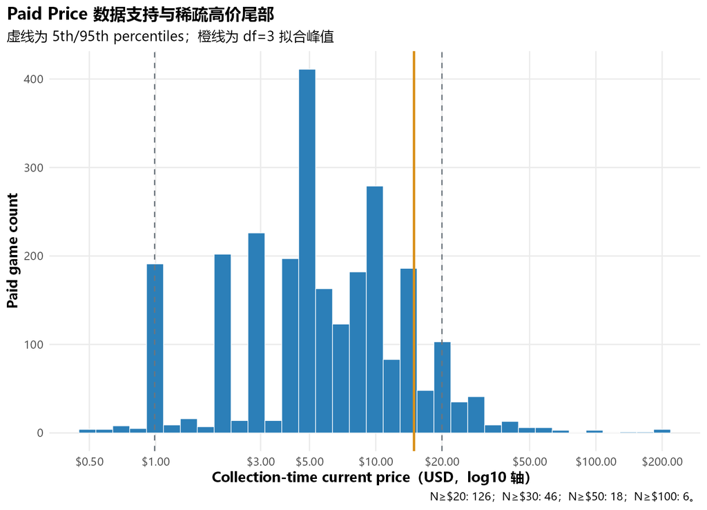

图 16: Price curve 的 empirical support。应该看什么：$0.99–$19.99 是主要解释区间，高价尾部观测很少。

Review-entry 模型的代表性结果

|  | Predictor | OR | CI low | CI high |
| --- | --- | --- | --- | --- |
| 2 | is_free | 0.015 | 0.010 | 0.021 |
| 6 | platform_segmentWindows + macOS + Linux | 1.999 | 1.209 | 3.304 |
| 9 | genre_casual | 0.661 | 0.528 | 0.828 |
| 12 | genre_simulation | 1.725 | 1.307 | 2.276 |

主要关联包括：free 的 entry odds 很低；三平台支持与较高 entry odds 相关；Simulation 与较高 entry odds 相关；Casual 与较低 entry odds 相关。所有结果仍是 composition-adjusted association。

## 7.3 Why raw review counts required a different strategy

Positive-count raw model 的诊断是方法选择的一部分，而不是应被隐藏的失败。Poisson Pearson dispersion 约为 `16,774`；ordinary NB2 的 `theta≈0.273`；truncated NB2 的 `theta≈1.3×10^-9`。虽然 truncated NB2 AIC 约为 `21,297`，但 residual distribution mismatch、extreme head concentration、tail sensitivity 和 price curve instability 仍然存在。

因此，项目没有因为 AIC 最低就冻结 raw count model，也没有为了得到显著结果继续增加未经预设的复杂模型。注意力强度的 estimand 改为有序 tiers，是比继续修补单一 count likelihood 更透明的选择。

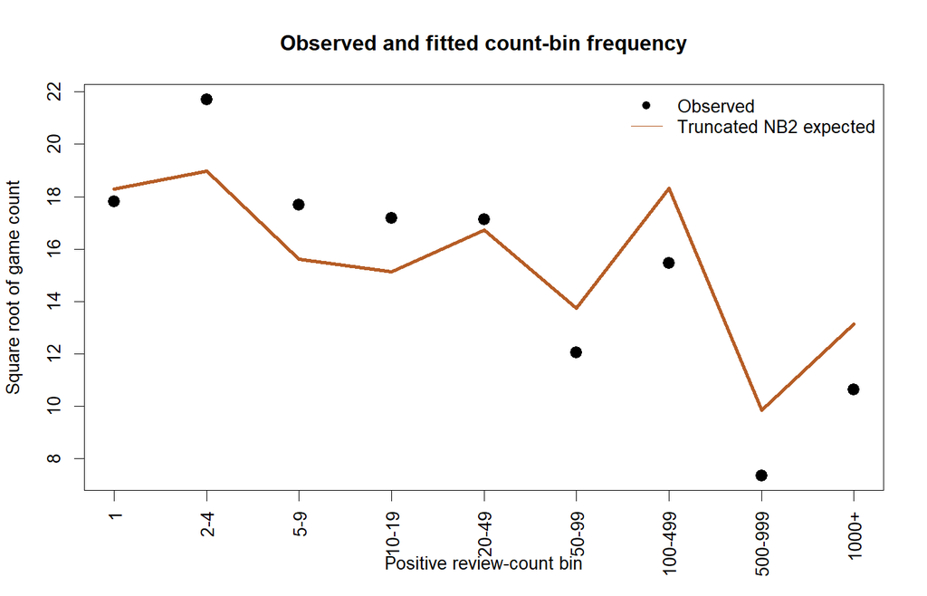

图 17: Raw count model 的诊断案例。应该看什么：模型选择由 estimand 与诊断共同决定，而不是由单个 AIC 排名决定。

# 8 Attention tiers：稳定的 portfolio-level intensity model

## 8.1 Tier reformulation

在 `total_reviews>0` 的 2,241 款游戏中定义：

- Tier 1：1–9 reviews，49.17%；
- Tier 2：10–99 reviews，32.71%；
- Tier 3：100–999 reviews，13.07%；
- Tier 4：1,000+ reviews，5.04%。

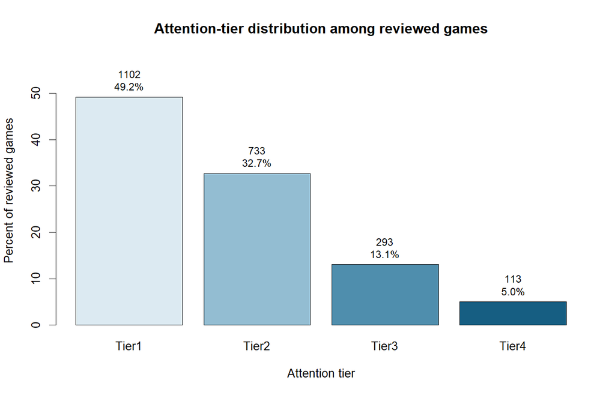

图 18: 四级 attention tier 分布。应该看什么：tier 化压缩了极端长尾，但保留了关注度的有序信息。

## 8.2 Ordinal Logistic Regression

最终主模型为 cumulative / proportional-odds ordinal logistic：

$$\log\frac{P(Y\le k)}{P(Y>k)} = \alpha_k - X\beta.$$

它研究的是 predictor 与“进入更高 attention tier”的关联，而不是评论数增加多少倍。模型保留 `is_free`、paid price Natural Spline df=3、`log(days_since_release)`、platform segment 与七个 genre；不使用 offset。

Attention tier ordinal model 的代表性 OR

|  | Predictor | OR | CI low | CI high |
| --- | --- | --- | --- | --- |
| 1 | is_free | 0.508 | 0.249 | 1.034 |
| 5 | log_days | 2.756 | 1.600 | 4.749 |
| 8 | platform_segmentWindows + macOS + Linux | 1.791 | 1.317 | 2.435 |
| 10 | genre_adventure | 1.302 | 1.098 | 1.544 |
| 13 | genre_rpg | 1.310 | 1.068 | 1.606 |
| 14 | genre_simulation | 1.436 | 1.185 | 1.740 |
| 15 | genre_strategy | 0.860 | 0.697 | 1.059 |

Proportional-odds audit 使用三个 threshold-specific logits（`>=10`、`>=100`、`>=1000`）。部分弱效应在边界间变化，因此结论为 `APPROXIMATE`；但没有 major direction reversal，High-100 robustness 为 PASS。

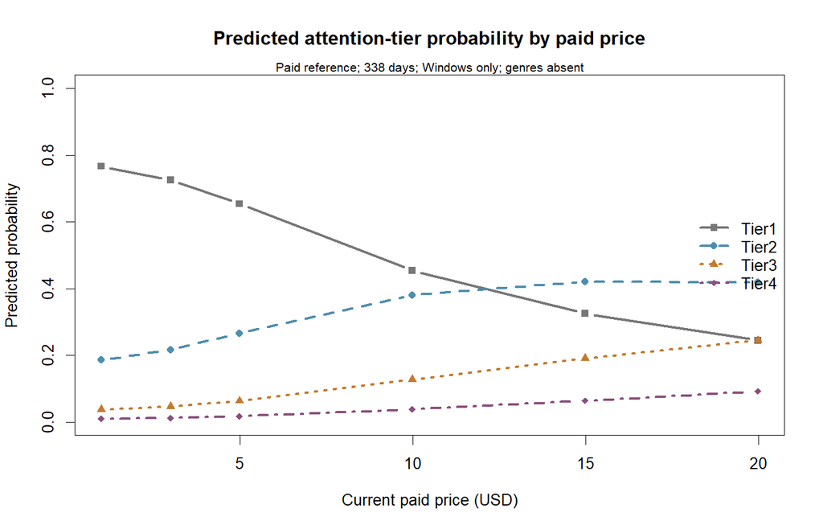

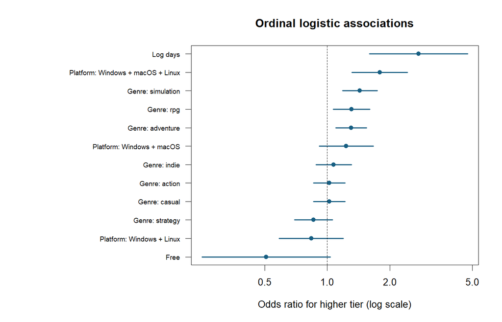

图 20: Ordinal attention-tier OR。应该看什么：三平台、Adventure、RPG、Simulation 与更高 tier 的关联方向；free subgroup 稀疏。

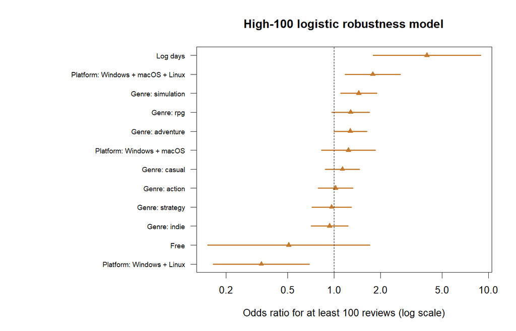

图 21: High-100 logistic robustness check。应该看什么：主要方向与 ordinal model 广泛一致；它是稳健性检查，不替代 ordinal primary。

# 9 Attention vs Reception：跨模型比较

Attention 和 reception 是不同 outcome，不能比较 OR 的数值大小，只比较 direction / positive / negative / uncertain。最有解释价值的交叉结果是：Simulation 更容易进入较高 attention tier，但在条件 reception 模型中呈负向关联；multi-platform 在两个维度均呈正向；RPG、Adventure 的 attention 方向为正，但 reception 证据不足。

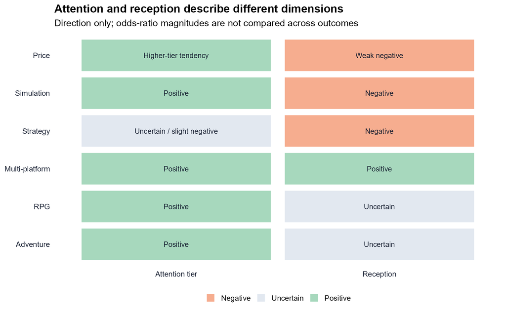

图 22: Attention 与 reception 的方向矩阵。应该看什么：关注度和口碑不是同一件事，Simulation 的跨模型方向差异尤其值得注意。

# 10 模型决策与方法论总结

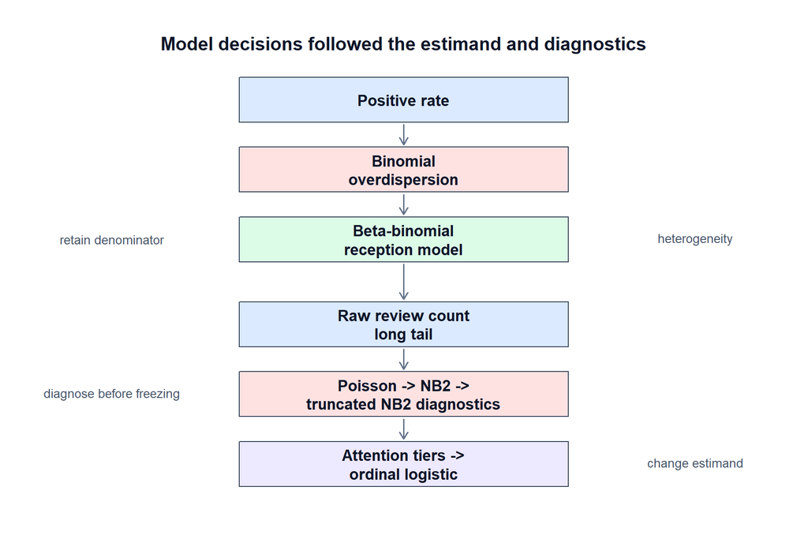

图 23: 模型决策图。应该看什么：每个统计模型对应一个明确 estimand，并且先经过 dispersion、tail、functional-form 或 reliability diagnostics。

## 10.1 五个统计经验

1. **Denominator matters**：比例不能脱离分母；Wilson 和 Beta-binomial 都显式保留这一点。
2. **Overdispersion matters**：真实市场的游戏间异质性可以远大于 Binomial / Poisson 假设。
3. **Functional form matters**：paid price 的线性项会掩盖 review-entry 的非线性结构。
4. **Diagnostics matter**：AIC 最低不等于模型可用；tail、残差、稳定性和支持范围同样重要。
5. **Estimand matters**：raw count 不稳定时，改成有序 attention tiers 比继续堆叠复杂模型更符合研究目标。

# 11 主要结论

1. 3,000 款样本中 25.30% 没有 Steam 评论，评论 entry 本身就是重要的市场分化。
2. 评论 attention 极度集中：Top 1% 游戏贡献约 65.44% 的正评论量。
3. raw positive rate 在低 denominator 下高度不可靠；Wilson 与 EB 提供了不同用途的可靠性辅助。
4. Beta-binomial 是 reception 的主要推断模型，标准 Binomial 的严重 overdispersion 不能忽略。
5. Price 与 reception 呈弱负向条件关联；Simulation reception 为稳定负向，Strategy 总体负向但较敏感。
6. Review-entry 的 paid-price relationship 是明显 nonlinear，中央支持区是宽平台而不是单一最优价格。
7. 原始 positive-count model 因 extreme tail 和诊断问题未冻结，失败记录作为方法论案例保留。
8. Ordered attention-tier model 提供了更稳定、可解释的 portfolio-level intensity 描述。
9. Attention 与 reception 是两个不同维度；高关注不自动意味着更高口碑。

# 12 限制与不作出的声明

## 12.1 研究限制

- single snapshot，不能代表随时间变化的生命周期结果；
- price 是 current storefront price，不是 launch price；
- 没有 sales、owners、revenue、marketing spend 或真实曝光数据；
- observational design，存在未观测的 marketing、brand、quality 和发行策略；
- genre 是 multi-label；
- positive-count free subgroup 稀疏；
- attention tiers 会牺牲 tier 内的原始 count 差异；
- ordinal proportional-odds assumption 仅 approximate；
- 所有回归结果均为 conditional association，不是 causal effect。

## 12.2 本项目不声称

- price causes attention 或 better ratings；
- platform causes better ratings；
- reviews equal sales；
- Empirical Bayes score 等于真实 game quality；
- `$14–15` 是 optimal pricing；
- Simulation games are inherently worse。

# 13 技术栈、复现与冻结状态

## 13.1 Technical stack

- **Python**：Steam collection、ETL、抽样与可复现数据处理；
- **MySQL**：分析型关系数据库；
- **R**：EDA、回归、诊断、敏感性与可视化；
- **Quarto**：可复现 HTML 报告；
- **Git**：版本控制与审计轨迹。

主要 runner 包括 `R/run_eda.R`、`R/run_rating_adjustment.R`、`R/run_attention_entry.R`、`R/run_attention_entry_nonlinear.R`、`R/run_attention_count.R` 和 `R/run_attention_tier.R`。本报告只读取已经冻结的 CSV 和 PNG 产物，不重新拟合模型。

## 13.2 Reproducibility audit

当前完整测试套件为 `270 passed`；MySQL 数据库只读且对象计数未改变；credential safety PASS；Step 6B.1 attention-tier model 已冻结，attention analysis 已关闭。HTML 报告不打印 `.env`、密码、用户名或数据库连接输出。

## 13.3 Final status

```yaml
Data collection / sampling: FROZEN
MySQL analytical database: FROZEN
SQL exploration: FROZEN
R EDA: FROZEN
Reception models: FROZEN
Attention entry and nonlinear price: FROZEN
Raw positive-count model: DIAGNOSTIC FAIL / RETAINED
Attention-tier ordinal model: FROZEN
Full statistical analysis report: COMPLETE
Ready for GitHub / portfolio presentation: YES
```